# Анализ мощности, часть 1

## Математические методы в зоологии - на R, осень 2013

Марина Варфоломеева  
Каф. Зоологии беспозвоночных, СПбГУ

# Экономим силы с помощью анализа мощности

- Статистические ошибки при проверке гипотез
- Мощность статистического теста
- *A priori* анализ мощности
- Оценка величины эффекта

# Вы сможете

- дать определение ошибок I и II рода, и графически изобразить их отношение к мощности теста
- оценивать величину эффекта и необходимый объем выборки по данным пилотного исследования
- загружать данные из .xls в R
- строить гистограммы и боксплоты с помощью `ggplot2`

# Статистические ошибки при проверке гипотез

# Типы ошибок при проверке гипотез

|  | H0 == TRUE | H0 == FALSE |
| --- | --- | --- |
| Отклонить H0 | Ошибка I рода Ложно-положительный результат | Верно Положительный результат |
| Сохранить H0 | Верно Отрицательный результат | Ошибка II рода Ложно-отрицательный результат |

# Вероятности гипотез

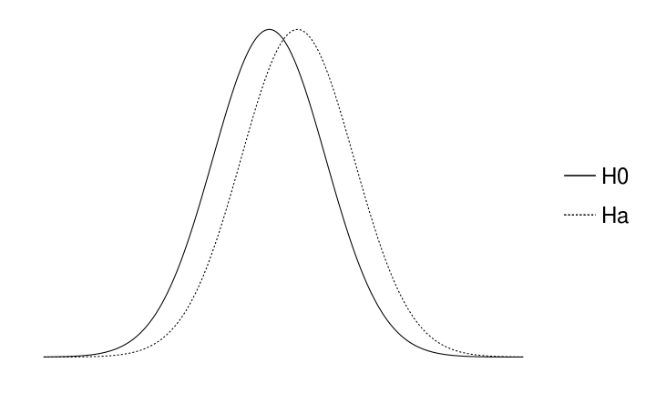

# Ошибки I рода

$H _0$ верна, но отвергнута, найдены различия - ложно-положительный результат

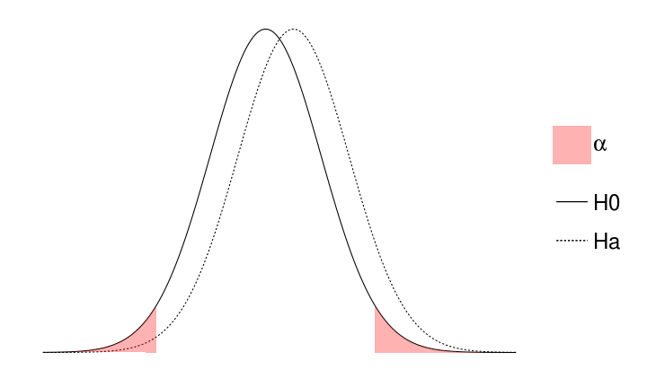

# Ошибки II рода

$H _0$ не верна и сохранена, не найдены различия - ложно-отрицательный результат

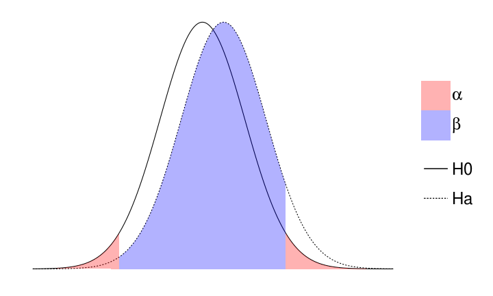

# Мощность теста

способность выявлять различия

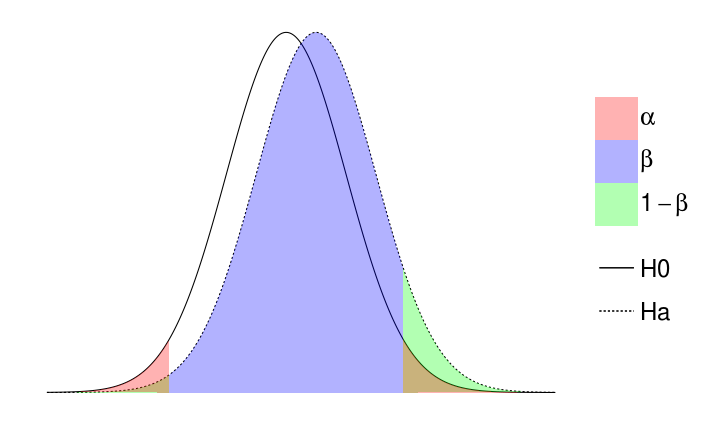

$$Power = 1 – \beta$$

# Анализ мощности

*A priori*

- какой нужен объем выборки, чтобы найти различия с разумной долей уверенности?
- различия какой величины мы можем найти, если известен объем выборки?

*Post hoc*

- смогли бы мы найти различия при помощи нашего эксперимента ($\alpha$, $n$), если бы величина эффекта была $X$?

# A priory анализ мощности

# Для a priori анализа нужно знать

- тест
- уровень значимости
- желаемая мощность теста—80%
- ожидаемая величина эффекта

# Пример: Заповедник спасает халиотисов *

Лов халиотисов (коммерческий и любительский) запретили, организовав заповедник.

Стало ли больше моллюсков через несколько лет? (Keough, King, 1991)

# Что мы знаем для a priori анализа?

- тест
- уровень значимости
- желаемая мощность теста
- ожидаемая величина эффекта

# Что мы знаем для a priori анализа?

- тест — $t$-критерий
- уровень значимости — $alpha = 0.05$
- желаемая мощность теста — 80%
- ожидаемая величина эффекта — ?

# Величина эффекта

# Величина эффекта

$d$ Коэна (Cohen's d)

$$d = \frac{\bar \mu_1 - \bar \mu_2}{\sigma}$$

# Как оценить стандартное отклонение для расчета величины эффекта?

$$d = \frac{\bar \mu_1 - \bar \mu_2}{\sigma}$$

- как среднеквадратичное стандартное отклонение
  ($d$ Коэна) $$d={{|\bar x _1 - \bar x _2 |} \over {\sqrt{{s_1^2 + s_2^2 } \over {2} }}}$$
- как обобщенное стандартное отклонение
  ($g$ Хеджа) $$g={ {|\bar x _1 - \bar x _2|} \over {\sqrt{{(n _1 - 1)s_1^{2} + (n _2 - 1)s_2^{2} } \over {n _1 + n _2 - 2} } }}$$

# Как оценить ожидаемую величину эффекта?

- Пилотные исследования
- Литература
- Общебиологические знания
- Технические требования

# Величина эффекта из общих соображений

Яков Коэн (1982)

сильные, умеренные и слабые эффекты

```r
library(pwr)
cohen.ES(test = "t", size = "large")
```

```
##
##      Conventional effect size from Cohen (1982)
##
##            test = t
##            size = large
##     effect.size = 0.8
```

# Величина эффекта из пилотных данных

${\sigma}$ - cтандартное отклонение плотности халиотисов:

Плотность крупных халиотисов на $50 м^2$

$$\bar x = 47.5$$ $$SD = 27.7$$

# Величина эффекта из пилотных данных

${\bar \mu_1 - \bar \mu_2}$ - cредний вылов халиотисов в год:

- Масса выловленных -> размер -> численность -> плотность
- Коммерческий лов ~ любительский лов

Коммерческий лов = 11.6 экз. $м^{-2}$

Коммерческий + любительский лов = 23.2 экз. $м^{-2}$

# Данные для анализа мощности собраны

```r
alpha <- 0.05
power <- 0.80
sigma <- 27.7 # варьирование плотности халиотисов
diff <- 23.2 # ожидаемые различия плотности халиотисов
effect <- diff/sigma # величина эффекта
effect
```

```
## [1] 0.838
```

# Считаем объем выборки

```r
pwr.t.test(n = NULL, d = effect, power = power, sig.level = alpha,
           type = "two.sample", alternative = "two.sided")
```

```
##
##      Two-sample t test power calculation
##
##               n = 23.4
##               d = 0.838
##       sig.level = 0.05
##           power = 0.8
##     alternative = two.sided
##
## NOTE: n is number in *each* group
```

- Чтобы с вероятностью 0.8 выявить различия плотности халиотисов в местах, где лов разрешен и запрещен, нужно обследовать **по 24 места каждого типа**, если мы верно оценили величину эффекта.

```r
cohen.ES(test = "t", size = "small")
```

```
##
##      Conventional effect size from Cohen (1982)
##
##            test = t
##            size = small
##     effect.size = 0.2
```

```r
pwr.t.test(n = NULL, d = 0.2, power = 0.8, sig.level = 0.01,
           type = "two.sample", alternative = "two.sided")
```

```
##
##      Two-sample t test power calculation
##
##               n = 586
##               d = 0.2
##       sig.level = 0.01
##           power = 0.8
##     alternative = two.sided
##
## NOTE: n is number in *each* group
```

# Пример: Улитки на устрицах в мангровых зарослях *

В каких зонах мангровых зарослей на устрицах предпочитают обитать улитки?

Minchinton, Ross, 1999

* - Данные из Quinn, Keough, 2002, Box 9-5, Fig 9-7

# Читаем данные из файла

Не забудте войти в вашу директорию для матметодов, например, так

```r
# setwd("C:\\Мои\ документы\\mathmethR\\) # в Windows
# setwd(/home/yourusername/mathmethR/) # в Linux

library(XLConnect)
wb <- loadWorkbook("./data/minch.xls")
minch <- readWorksheet(wb, sheet = 1)
```

```r
# можете попробовать, что получится
minch
head(minch)
```

# Структура данных

```r
str(minch)
```

```
## 'data.frame':    40 obs. of  6 variables:
##  $ Col1    : chr  "1" "2" "3" "4" ...
##  $ site    : chr  "A" "A" "A" "A" ...
##  $ zone    : chr  "SZ(-TR)" "SZ(-TR)" "SZ(-TR)" "SZ(-TR)" ...
##  $ limpt   : num  0.16 0.11 0.1 0.16 0.15 0.12 0 0.03 0.05 0.43 ...
##  $ limpt100: num  16 11 10 16 15 12 0 3 5 43 ...
##  $ sqlim100: num  4 3.32 3.16 4 3.87 ...
```

# Гистограмма числа улиток

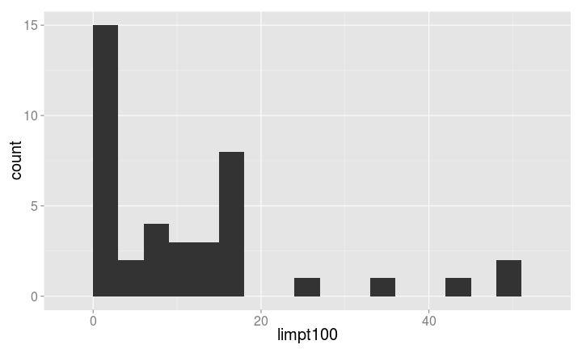

```r
library(ggplot2)
ggplot(data = minch, aes(x = limpt100)) + geom_histogram(stat = "bin", binwidth = 3)
```

# Раскрашиваем гистограмму

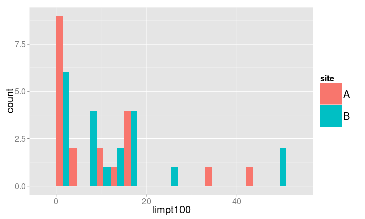

```r
hp <- ggplot(data = minch, aes(x = limpt100, fill = site)) +
  geom_histogram(stat = "bin", binwidth = 3, position = "dodge")
hp
```

# Называем оси, если нужно

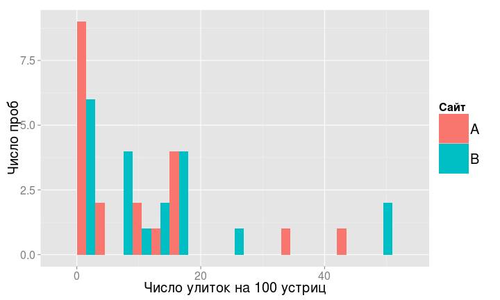

```r
hp <- hp +
  labs(x = "Число улиток на 100 устриц", y = "Число проб", fill = "Сайт")
hp
```

# Чтобы не переписывать все

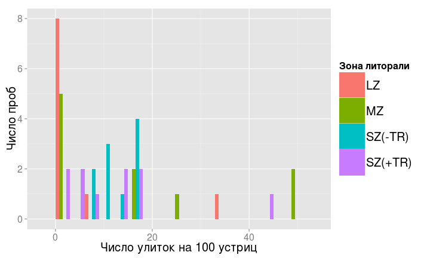

```r
# меняем только эстетику
hp + aes(fill = zone) +
  labs(fill = "Зона литорали")
```

# График с панелями

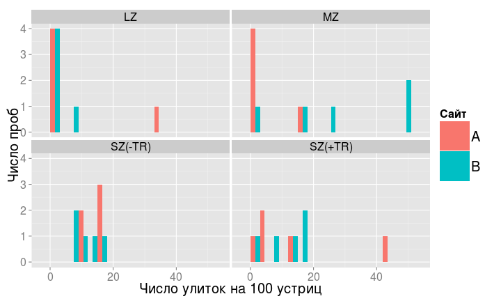

```r
hp + facet_wrap(~ zone)
```

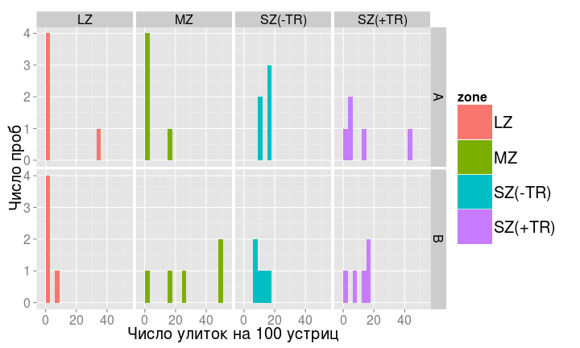

```r
# hp + aes(fill = limpt100) # ошибка, т.к. непрерывная шкала, вместо дискретной
# у эстетики должна быть дискретная шкала

# одновременно панели и раскрашивание
hp + facet_grid(site~zone) + aes(fill = zone)
```

# Боксплоты числа улиток

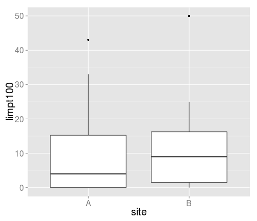

```r
bp <- ggplot(data = minch, aes(x = site, y = limpt100)) +
  geom_boxplot()
bp
```

# Дополнительные ресурсы

- Quinn, Keough, 2002, pp. 164-170
- Open Intro to Statistics: [4.6 Sample Size and Power](http://www.openintro.org/stat/down/oiStat2_04.pdf), pp. 193-197
- Sokal, Rohlf, 1995, pp. 167-169.
- Zar, 1999, p. 83.
- [R Data Analysis Examples - Power Analysis for Two-group Independent sample t-test. UCLA: Statistical Consulting Group.](http://www.ats.ucla.edu/stat/r/dae/t_test_power2.htm)
- [R Data Analysis Examples - Power Analysis for One-sample t-test. UCLA: Statistical Consulting Group.](http://www.ats.ucla.edu/stat/r/dae/t_test_power.htm)
- [FAQ - How is effect size used in power analysis? UCLA: Statistical Consulting Group.](http://www.ats.ucla.edu/stat/mult_pkg/faq/general/effect_size_power/effect_size_power.htm)